# Selección del mejor festival de música al que ir desde Sevilla

Trabajo 2 · Decisión multicriterio (AHP, ELECTRE, PROMETHEE, TOPSIS…)

Autor/a

Carla Garzoli Serrano

Fecha de publicación

10 de noviembre de 2026

# 1 Motivación del problema

Los festivales son uno de los eventos más solicitados por los jóvenes. Ya que en ellos puedes vivir experiencias increíbles y escuchar a cantantes de todas las partes del mundo en único lugar. Cada verano Andalucía y el resto de la península acogen festivales de música. Desde Sevilla hay opciones para todos los gustos y sobre todo, para todo tipo de economías. Encontrando festivales en la propia ciudad, a los que se llega en autobús, hasta festivales de cuatro días en diferentes partes de España, que obligan a viajar cientos de kilómetros y a pagar alojamiento. La gran pregunta de mi trabajo es: **“¿A cuál merece más la pena ir?”**

La respuesta no es obvia porque los criterios están en constante conflicto, los festivales con mejor cartel suelen ser los más caros y los más lejano. Los más cómodos están al lado de casa, pero quizá tengan un cartel menos atractivo. Por eso se plantea como un **problema de decisión multicriterio**, es decir, tendremos un conjunto de alternativas (festivales de la temporada 2027), evaluadas con varios criterios, con un decisor concreto (en este caso los estudiantes).

**NotaPerfil del decisor**

Estudiante que viaja desde Sevilla, con gusto por el pop, el rock y el indie, presupuesto normal y que viaja en coche compartido entre 4 personas cuando el festival está fuera de Sevilla. Los juicios como cartel y logística y los pesos de los criterios reflejan ese perfil y pueden cambiarse en la matriz de decisión del documento y en el fichero `festivales.ahp` que también he adjuntado como parte de mi trabajo. El resto del trabajo se recalcula al renderizarlo.

En este trabajo se resuelve el mismo problema con las técnicas vistas en clase y se comparan los resultados: **AHP** (con el paquete `ahp` ([paquete ahp](https://github.com/gluc/ahp))), **ELECTRE I**, **PROMETHEE I y II**, **TOPSIS** y el **método axiomático de Arrow y Raymond**. Las funciones de ELECTRE, PROMETHEE, TOPSIS, etc. son las del paquete de la asignatura (TDecisionCodigo).

# 2 Alternativas

Se consideran seis festivales de la temporada 2027, desde dos celebrados en la propia ciudad hasta cuatro que obligan a viajar entre 250 y 700 km:

Festivales considerados (temporada 2027).

| Festival | Lugar | Fechas | Días | Estilo |
| --- | --- | --- | --- | --- |
| Icónica Sevilla Fest 2027 | Sevilla (Plaza de España) | jun-jul 2027 | 1 concierto | Pop / rock / latino |
| Interestelar Sevilla 2027 | Sevilla (CAAC, Cartuja) | mayo 2027 (por confirmar) | 2 | Indie / pop alternativo |
| Weekend Beach Festival 2027 | Torre del Mar (Málaga) | julio 2027 (por confirmar) | 3 | Urbano / pop / rock |
| Dreambeach Villaricos 2027 | Villaricos (Almería) | agosto 2027 (por confirmar) | 5 | Electrónica |
| Mad Cool 2027 | Madrid | julio 2027 (por confirmar) | 4 | Rock / indie / pop |
| Arenal Sound 2027 | Burriana (Castellón) | 29 jul-1 ago 2027 | 4 | Indie / urbano / pop / electrónica |

Siendo las fuentes de donde proceden:

- **Icónica Sevilla Fest** ([fuente](https://www.que.es/2026/11/06/iconica-sevilla-fest-2027/)). Ciclo de conciertos en la Plaza de España de Sevilla en junio y julio de 2027. Se evalúa la asistencia a **un** concierto: entrada de unos 65 € (hay desde 36 €) + 3 € de autobús. Coste 68 €, 25 min de viaje.
- **Interestelar Sevilla** ([fuente](https://www.festivalesdeespana.com/festival/interestelar-sevilla-sevilla)). Festival indie y pop alternativo en el CAAC de la Cartuja (Sevilla), dos días en mayo. Abono de 2 días estimado en 90 € (+3 € de autobús): 93 €, 25 min.
- **Weekend Beach Festival** ([fuente](https://www.laganzua.net/festivales/festival-weekend-beach-torre-del-mar-2025-velez-malaga-1008242)). Festival de playa en Torre del Mar (Málaga), en julio, con cartel urbano y pop. Abono 82,50 € (precio de 2025) + 3 noches a 30 € + coche compartido (250 km): 191,25 €, 2 h 45 min.
- **Dreambeach Villaricos** ([fuente](https://www.taquilla.com/entradas/festival-dreambeach-villaricos)). Festival de música electrónica en la playa de Villaricos (Almería), en agosto, con acampada. Abono 75 € + 4 noches a 15 € + coche compartido (500 km): 172,50 €, 5 h 10 min.
- **Mad Cool** ([fuente](https://www.laganzua.net/conciertos/mad-cool-festival-2026-madrid-1013806)). Gran festival de rock, indie y pop en Madrid, cuatro días en julio. Abono 240 € (precio de 2026) + 4 noches a 40 € + coche compartido (530 km): 439,75 €, 5 h 5 min.
- **Arenal Sound** ([fuente](https://www.dodmagazine.es/festivales/arenal-sound/)). Festival de playa en Burriana (Castellón), del 29 de julio al 1 de agosto de 2027, con acampada. Abono general 75 € ([precio de 2026](https://www.doyouspain.com/blog/es/festivales-castellon-2026-informacion); la preventa de 2027 fue de 54,99 € para los primeros 3.000) + 4 noches de acampada a 20 € (supuesto) + coche compartido (700 km): 207,50 €, 7 h.

**AdvertenciaSobre los datos**

Los datos de los festivales de 2027 aún no están todos cerrados.Se han usado las fechas de 2027 cuando ya están anunciadas en el caso de Arenal Sound, Icónica y los precios de 2027 solo cuando existen Icónica.En el resto, los de la última edición conocida, indicándolo arriba.Algunos valores son estimaciones como el precio del abono de Interestelar,alojamiento por noche, kilómetros y tiempos de viaje por carretera (según mi criterio) y las dos valoraciones subjetivas que son cartel y logística.

# 3 Criterios

El coste, el tiempo y la sostenibilidad se miden con datos objetivos.El cartel y la logística se valoran en una escala subjetiva de 1 a 10.

Criterios del problema.

| Criterio | Qué mide | Escala | Objetivo |
| --- | --- | --- | --- |
| C1. Coste | Coste total por persona: entrada o abono + alojamiento + viaje de ida y vuelta (coche compartido) + gastos locales | € | minimizar |
| C2. Tiempo | Tiempo de viaje de ida desde Sevilla | minutos | minimizar |
| C3. Cartel | Atractivo del cartel para un perfil pop-rock-indie | 1-10 | maximizar |
| C4. Logística | Facilidad de alojamiento y de volver a casa (dormir en casa = 10) | 1-10 | maximizar |
| C5. Sostenibilidad | Emisiones de CO<sub>2</sub> del viaje de ida y vuelta por persona | kg CO<sub>2</sub> | minimizar |

Supuestos del viaje en coche:

Recordamos que el problema se basa en **4 personas por coche**,0,15 € por km de vehículo repartidos entre los ocupantes,y 0,17 kg de CO<sub>2</sub> por km de coche (repartidos entre los ocupantes) frente a 0,09 kg por pasajero-km en transporte público urbano.Además, asumo que el alojamiento se supone compartido.

## 3.1 Matriz de decisión

Para los métodos que trabajan con una matriz de decisión (ELECTRE, PROMETHEE, TOPSIS, Arrow y Raymond) se sigue el criterio de **mayor valor es mejor**.Por eso los criterios que hay que minimizar (coste, tiempo y emisiones) se introducen cambiados de signo.

|  | Coste | Tiempo | Cartel | Logistica | Sostenibilidad |
| --- | --- | --- | --- | --- | --- |
| Iconica | -68.00 | -25 | 8 | 10 | -1.08 |
| Interestelar | -93.00 | -25 | 6 | 10 | -1.08 |
| WeekendBeach | -191.25 | -165 | 6 | 6 | -21.25 |
| Dreambeach | -172.50 | -310 | 4 | 4 | -42.50 |
| MadCool | -439.75 | -305 | 9 | 6 | -45.05 |
| ArenalSound | -207.50 | -420 | 5 | 5 | -59.50 |

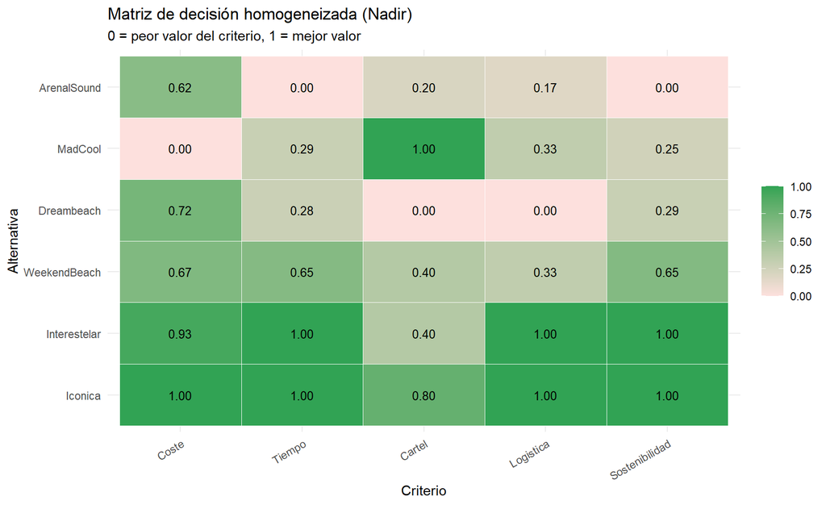

Figura 1: Matriz de decisión homogeneizada con el método Nadir (0 = peor valor del criterio, 1 = mejor).

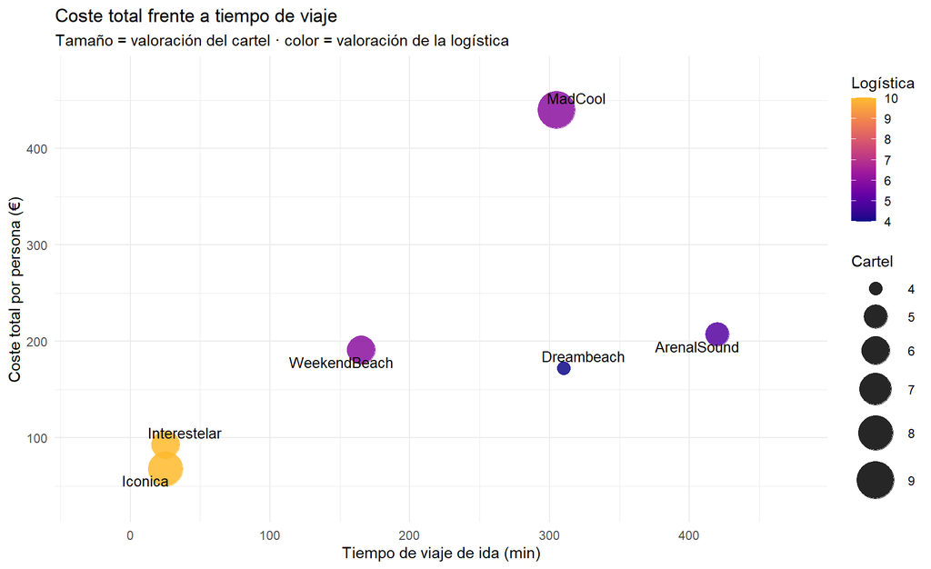

Figura 2: Coste total y tiempo de viaje de cada festival. Los de Sevilla están en la izquierda y los grandes carteles a la derecha.

# 4 Método AHP

- **Criterios.** Los juicios entre criterios se han hecho pensando en el perfil descrito.El cartel es lo más importante, seguido del coste y, a distancia, tiempo y logística. La sostenibilidad es el criterio de menor peso.
- **Alternativas.** En cada criterio se comparan los festivales por pares con la escala de 1 a 9. En coste, tiempo y emisiones, cuantas veces es mejor un festival que otro.En cartel y logística, la diferencia de puntos: 1 punto de diferencia es un escalón de la escala.

El modelo está en el fichero `festivales.ahp` (formato del paquete `ahp`), con los festivales, la jerarquía de criterios y las comparaciones por pares:

[interactive chart not shown]

Figura 3: Jerarquía AHP del problema.

Pesos globales de los criterios que se usarán también en los demás métodos:

| Criterio | Peso global (%) |
| --- | --- |
| Coste | 24.49 |
| Tiempo | 12.97 |
| Cartel | 43.80 |
| Logistica | 12.25 |
| Sostenibilidad | 6.49 |

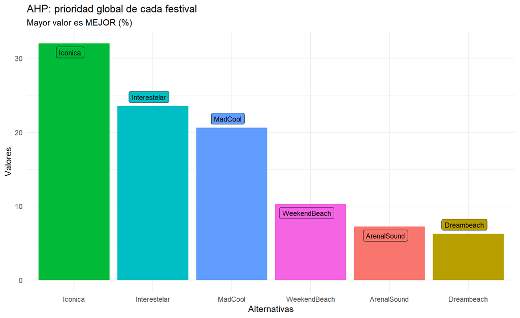

Figura 4: AHP: prioridad global de cada festival (%).

|  | Weight | Iconica | Interestelar | WeekendBeach | Dreambeach | MadCool | ArenalSound | Inconsistency |
| --- | --- | --- | --- | --- | --- | --- | --- | --- |
| Elegir el mejor festival | 100.0% | 32.0% | 23.5% | 10.3% | 6.3% | 20.6% | 7.3% | 0.3% |
| Coste | 24.5% | 8.0% | 6.4% | 2.9% | 3.1% | 1.3% | 2.9% | 0.5% |
| Tiempo | 13.0% | 5.2% | 5.2% | 1.0% | 0.5% | 0.5% | 0.5% | 1.2% |
| Cartel | 43.8% | 11.7% | 4.9% | 4.9% | 2.0% | 17.4% | 3.0% | 1.7% |
| Logistica | 12.2% | 4.5% | 4.5% | 1.1% | 0.5% | 1.1% | 0.7% | 1.8% |
| Sostenibilidad | 6.5% | 2.6% | 2.6% | 0.5% | 0.3% | 0.3% | 0.2% | 2.1% |

**TipConclusiones**

Viendo la tabla global se observa que el festival más valorado es Icónica Sevilla Fest, con una prioridad del 32 %, seguido de Interestelar Sevilla con un 23,5 % y de Mad Cool con un 20,6 %.El resto de festivales quedan bastante por debajo como Weekend Beach 10,3 %, Arenal Sound 7,3 % y Dreambeach 6,3 %.Lo que indica una preferencia por los festivales que se hacen en la propia ciudad (Sevilla) y no por aquellos que obligan a viajar y a pagar alojamiento.

El criterio que más pesa es el cartel,con un 43,8 % del peso total,lo que refleja que lo más importante para este perfil es la música. Le siguen el coste 24,5 %, el tiempo de viaje 13 % y la logística 12,3 %, mientras que la sostenibilidad tiene un papel muy secundario 6,5 %. Aun así vemos que el cartel no basta para ganar, Mad Cool tiene el mejor cartel, pero es el festival más caro y por eso solo queda tercero.

De las tablas de prioridades locales vemos que Icónica e Interestelar ganan o empatan como mejores en casi todos los criterios. Los dos obtienen el mismo valor en tiempo 40,1 %, logística 36,3 % y sostenibilidad 40,7 % porque ambos son en Sevilla, y Icónica gana en coste 32,8 % frente a 26 % y en cartel 26,7 % frente a 11,1 %. Mad Cool destaca claramente en el cartel 39,8 %, pero es el peor en coste 5,3 %. Weekend Beach, Dreambeach y Arenal Sound no destacan en ningún criterio y tienen valores bajos en tiempo y sostenibilidad por las distancias, sobre todo Arenal Sound, que es el que está más lejos de Sevilla.

Por último, la inconsistencia es muy baja, es del 0,3 % en la matriz de los criterios y como mucho del 2,1 % en las de los festivales, muy por debajo del límite del 10 %. Por tanto, las comparaciones son coherentes entre sí.

La segunda tabla muestra las prioridades **locales**, es decir, cómo se ordenan las alternativas dentro de cada criterio:

|  | Priority | Iconica | Interestelar | WeekendBeach | Dreambeach | MadCool | ArenalSound | Inconsistency |
| --- | --- | --- | --- | --- | --- | --- | --- | --- |
| Elegir el mejor festival | 100.0% |  |  |  |  |  |  | 0.3% |
| Coste | 24.5% | 32.8% | 26.0% | 11.7% | 12.5% | 5.3% | 11.7% | 0.5% |
| Tiempo | 13.0% | 40.1% | 40.1% | 7.8% | 4.1% | 4.1% | 3.9% | 1.2% |
| Cartel | 43.8% | 26.7% | 11.1% | 11.1% | 4.5% | 39.8% | 6.8% | 1.7% |
| Logistica | 12.2% | 36.3% | 36.3% | 9.0% | 3.7% | 9.0% | 5.6% | 1.8% |
| Sostenibilidad | 6.5% | 40.7% | 40.7% | 7.0% | 3.9% | 3.9% | 3.8% | 2.1% |

# 5 Método PROMETHEE

Los pesos son los obtenidos con AHP (`criterios_sub`, suman 1). Para cada criterio se elige la función de preferencia que mejor representa cómo se percibe la diferencia:

Funciones de preferencia de PROMETHEE.

| Criterio | Función de preferencia | Parámetros | Justificación |
| --- | --- | --- | --- |
| C1 Coste | Lineal con indiferencia (5) | q = 20 €, p = 200 € | Diferencias de menos de 20 € son irrelevantes; a partir de 200 € la preferencia es total |
| C2 Tiempo | Lineal con indiferencia (5) | q = 30 min, p = 240 min | 30 min de más no importan; 4 horas de diferencia sí |
| C3 Cartel | Lineal (3) | p = 5 puntos | Cuanto más distinto el cartel, más preferencia |
| C4 Logística | Lineal (3) | p = 6 puntos | Dormir en casa o no es una diferencia grande |
| C5 Sostenibilidad | Gaussiana (6) | s = 15 kg | Preferencia suave que crece con las emisiones evitadas |

Matriz con las funciones de preferencia de cada criterio (columnas: número de función, q, p y s). Los pesos son los de AHP y suman 1.

Matriz de funciones de preferencia.

|  | Función | q | p | s |
| --- | --- | --- | --- | --- |
| Coste | 5 | 20 | 200 | 0 |
| Tiempo | 5 | 30 | 240 | 0 |
| Cartel | 3 | 0 | 5 | 0 |
| Logistica | 3 | 0 | 6 | 0 |
| Sostenibilidad | 6 | 0 | 1 | 15 |

## 5.1 PROMETHEE I

PROMETHEE I: relación de superación.

|  | Iconica | Interestelar | WeekendBeach | Dreambeach | MadCool | ArenalSound |
| --- | --- | --- | --- | --- | --- | --- |
| Iconica | 0.5 | 1.0 | 1.0 | 1.0 | 1.0 | 1.0 |
| Interestelar | 0.0 | 0.5 | 1.0 | 1.0 | 1.0 | 1.0 |
| WeekendBeach | 0.0 | 0.0 | 0.5 | 1.0 | 0.0 | 1.0 |
| Dreambeach | 0.0 | 0.0 | 0.0 | 0.5 | 0.0 | 0.0 |
| MadCool | 0.0 | 0.0 | 0.0 | 1.0 | 0.5 | 1.0 |
| ArenalSound | 0.0 | 0.0 | 0.0 | 1.0 | 0.0 | 0.5 |

Y los flujos de cada festival:

PROMETHEE I: flujos de cada festival.

|  | Rango | Phi | Phi.mas | Phi.menos |
| --- | --- | --- | --- | --- |
| Iconica | 1 | 0.5243 | 0.5419 | 0.0175 |
| Interestelar | 2 | 0.2910 | 0.3799 | 0.0890 |
| WeekendBeach | 3 | -0.0148 | 0.1975 | 0.2123 |
| MadCool | 4 | -0.0702 | 0.3079 | 0.3781 |
| ArenalSound | 5 | -0.3460 | 0.0706 | 0.4166 |
| Dreambeach | 6 | -0.3843 | 0.0693 | 0.4536 |

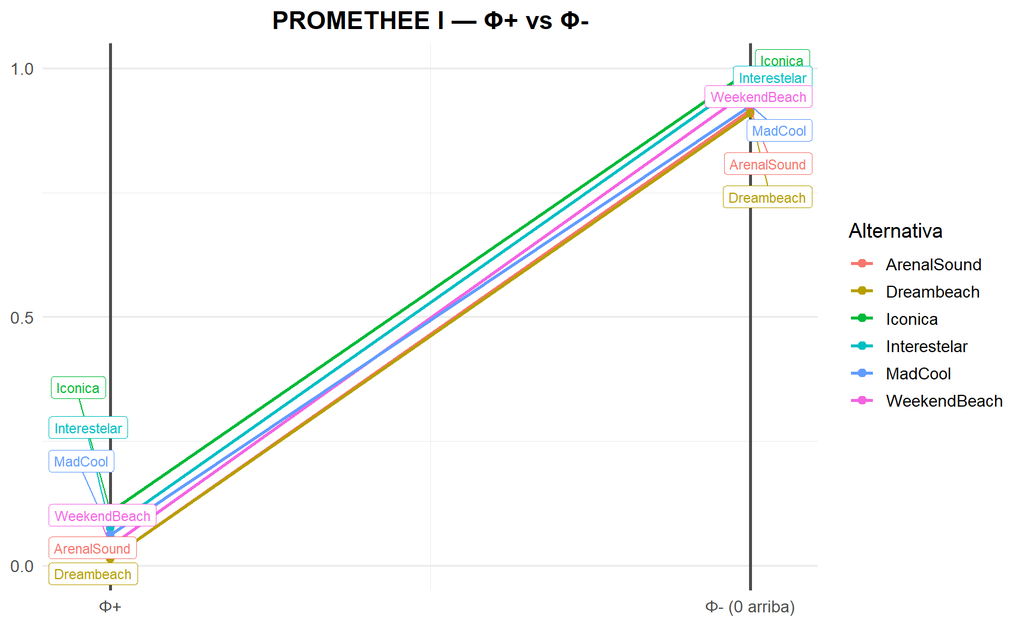

PROMETHEE I: flujos Φ+ y Φ- de cada festival.

**TipConclusiones**

En la tabla de relaciones de superación se observa que Icónica supera a los otros cinco festivales y no es superada por ninguno, por lo que es claramente la mejor opción. Interestelar supera a cuatro festivales y solo es superada por Icónica.Weekend Beach y Mad Cool superan cada uno a dos festivales, y Dreambeach no supera a ninguno y es superado por los otros cinco.

Los flujos confirman esta ordenación, siendo Icónica la que tiene el mayor flujo saliente y un flujo entrante casi nulo, mientras que Dreambeach y Arenal Sound tienen los flujos salientes más bajos y los entrantes más altos.

## 5.2 PROMETHEE II

El flujo neto de cada festival da la ordenación completa:

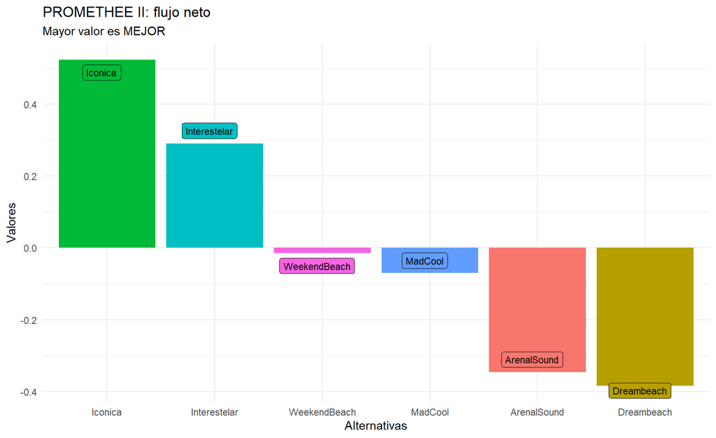

PROMETHEE II: flujo neto de cada festival.

PROMETHEE II: ordenación por flujo neto.

| Posición | Festival | Flujo neto |
| --- | --- | --- |
| 1 | Iconica | 0.52 |
| 2 | Interestelar | 0.29 |
| 3 | WeekendBeach | -0.01 |
| 4 | MadCool | -0.07 |
| 5 | ArenalSound | -0.35 |
| 6 | Dreambeach | -0.38 |

**TipConclusiones**

Con PROMETHEE II se obtiene una ordenación completa a partir del flujo neto: Icónica 0,52, Interestelar 0,29,Weekend Beach -0,01,Mad Cool -0,07,Arenal Sound -0,35 y Dreambeach -0,38.Solo Icónica e Interestelar tienen un flujo neto claramente positivo, es decir, superan en conjunto a más festivales de los que las superan a ellos.

Weekend Beach y Mad Cool tienen un flujo neto negativo pero muy cercano a cero, muy por debajo de Icónica e Interestelar, lo que encaja con lo visto en PROMETHEE I, donde no se podía decidir entre los dos.Al exigir una ordenación completa, Weekend Beach queda por delante porque es más barato y está más cerca.Los dos primeros puestos son iguales que en el AHP. La única diferencia es que el AHP pone a Mad Cool tercero por su cartel.

# 6 Método ELECTRE I

Partimos de alfa = 0,7 y definimos un veto en el coste (300 €) y en el tiempo de viaje (240 min).Esto significa que,por muy bueno que sea el cartel,no vale la pena un festival que cueste 300 € más ni uno que nos haga viajar 4 horas más.El resto de criterios no tienen veto.

ELECTRE I (alfa = 0,7): núcleo.

| Núcleo |
| --- |
| Iconica |
| MadCool |

Tras aplicar el método ELECTRE una vez, el núcleo está formado por Icónica y Mad Cool.Como seguimos teniendo dos alternativas y queremos quedarnos con una, repetimos el método solo con esas dos.

Seguimos teniendo el mismo núcleo, así que bajamos el nivel mínimo de concordancia a 0,55.

ELECTRE I (alfa = 0,55): núcleo.

| Núcleo |
| --- |
| Iconica |

Ahora el núcleo se queda solo con Icónica, que es el festival que ELECTRE I recomienda. Con otros umbrales de concordancia o de veto el resultado podría ser distinto.

**TipConclusiones**

Con alfa = 0,7 Icónica e Interestelar superan a casi todos los demás festivales, y solo Icónica y Mad Cool quedan sin ser superados. Entre ellos no hay un ganador claro puesto que Icónica es mejor en coste, tiempo, logística y sostenibilidad, y Mad Cool solo gana en cartel, que es el criterio con más peso.

Al bajar la concordancia a 0,55, Icónica supera a Mad Cool y el núcleo final queda solo con Icónica, igual que en el resto de métodos. Aun así, el resultado de ELECTRE depende del nivel de concordancia que se elija.

# 7 Método TOPSIS

| Alternativa | Separacion_ideal | Separacion_antiideal | Cerca_ideal | Rango |
| --- | --- | --- | --- | --- |
| Iconica | 0.0273 | 0.2199 | 0.8897 | 1 |
| Interestelar | 0.0825 | 0.1898 | 0.6969 | 2 |
| WeekendBeach | 0.1068 | 0.1358 | 0.5599 | 3 |
| MadCool | 0.1771 | 0.1395 | 0.4405 | 4 |
| Dreambeach | 0.1636 | 0.1193 | 0.4216 | 5 |
| ArenalSound | 0.1590 | 0.1050 | 0.3977 | 6 |

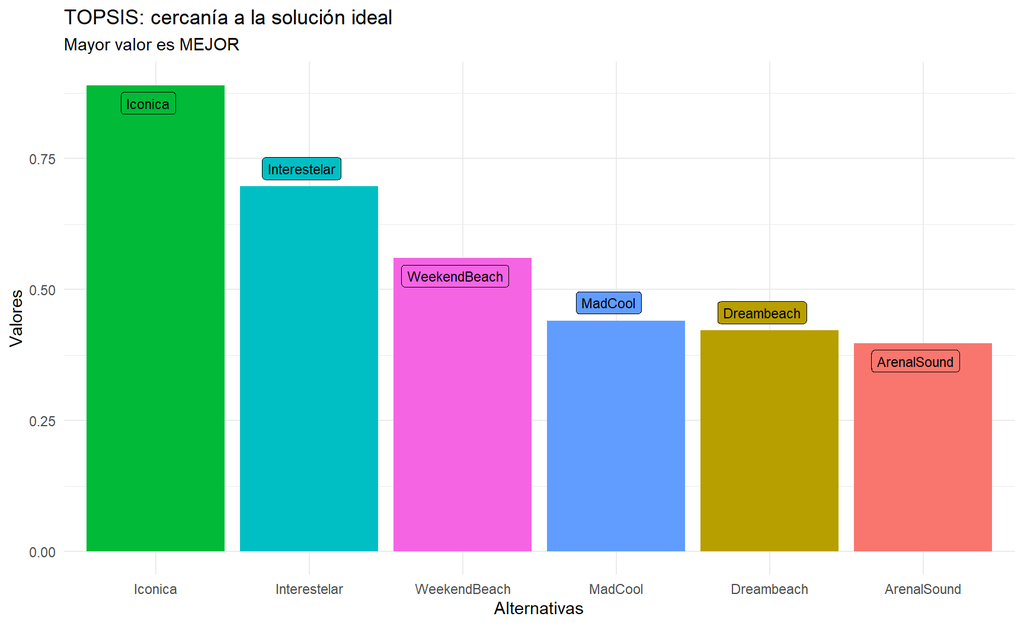

Figura 5: TOPSIS: cercanía relativa a la solución ideal.

**TipConclusiones**

Con TOPSIS el festival más cercano a la solución ideal es Icónica 0,89, con bastante diferencia sobre Interestelar 0,70 y Weekend Beach 0,56. Mad Cool 0,44, Dreambeach 0,42 y Arenal Sound 0,40 quedan al final con valores muy parecidos entre sí, así que sus posiciones son poco concluyentes.Una vez más el primer puesto es para Icónica, igual que en el resto de métodos.

# 8 Método axiomático de Arrow y Raymond

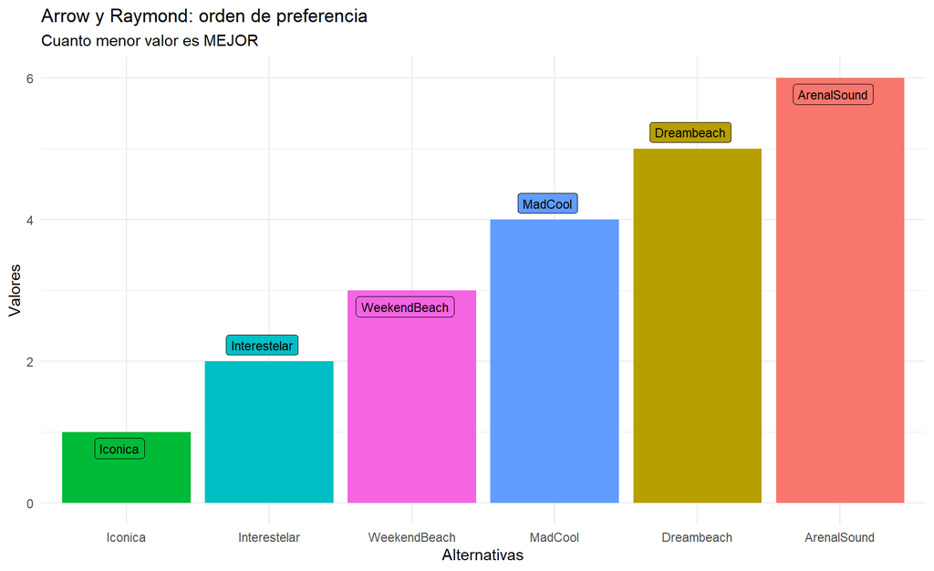

**TipConclusiones**

Este método ordena así: Icónica, Interestelar, Weekend Beach, Mad Cool, Dreambeach y Arenal Sound. Los cuatro primeros puestos son los mismos que con PROMETHEE II y TOPSIS, así que la elección de Icónica no depende de los pesos que hayamos dado. Solo cambian los dos últimos puestos, donde Arenal Sound queda último por ser el festival más lejano y con más emisiones.

# 9 Comparación de métodos

La siguiente tabla recoge la posición (1 = mejor) que da cada método a cada festival:

Posición (1 = mejor) que asigna cada método a cada festival.

|  | Rangos AHP | Rangos PROMETHEE II | Rangos TOPSIS | Rangos Arrow-Raymond |
| --- | --- | --- | --- | --- |
| Iconica | 1 | 1 | 1 | 1 |
| Interestelar | 2 | 2 | 2 | 2 |
| WeekendBeach | 4 | 3 | 3 | 3 |
| Dreambeach | 6 | 6 | 5 | 5 |
| MadCool | 3 | 4 | 4 | 4 |
| ArenalSound | 5 | 5 | 6 | 6 |

**TipConclusiones**

Viendo la tabla se observa que Icónica es la primera en los cuatro métodos e Interestelar es la segunda en todos ellos. Las diferencias aparecen en el resto: el AHP pone a Mad Cool tercero por su cartel, mientras que los otros tres métodos ponen a Weekend Beach tercero y a Mad Cool cuarto. En los dos últimos puestos están Arenal Sound y Dreambeach, que cambian de orden según el método. En conjunto, los métodos son coherentes entre sí y la variación está solo en los festivales intermedios y finales.

# 10 Conclusión final

| Método | Mejor festival |
| --- | --- |
| AHP | Iconica |
| PROMETHEE II | Iconica |
| TOPSIS | Iconica |
| Arrow-Raymond | Iconica |
| ELECTRE I | Iconica |

**TipCONCLUSIÓN**

**El mejor festival al que ir desde Sevilla, con los datos y las preferencias de este trabajo, es Icónica Sevilla Fest 2027**, que ocupa el primer puesto en los cinco métodos aplicados (AHP, PROMETHEE, ELECTRE I, TOPSIS y Arrow y Raymond). Interestelar Sevilla 2027 es la segunda opción.

Si el objetivo es **viajar a un festival fuera de Sevilla**, la mejor opción es Weekend Beach (PROMETHEE II, TOPSIS y Arrow y Raymond) o Mad Cool (AHP).

**NotaLimitaciones**

- Algunos datos de 2027 (precios, fechas, carteles) aún no están anunciados; se han usado los últimos conocidos y se han indicado como tales.
- Los criterios subjetivos (cartel y logística) y los juicios de comparación entre criterios reflejan un perfil concreto de decisor; otro perfil (por ejemplo, un aficionado a la electrónica) podría preferir otro festival. Basta con cambiar la matriz de decisión y el fichero `festivales.ahp` para recalcular todo.
- Las conclusiones están escritas con los datos entregados; si se cambian los datos, hay que revisarlos.

# Documentación utilizada

**Paquetes de R y material de la asignatura**

- TDecisionCodigo: funciones de la asignatura *Teoría de la Decisión* (ELECTRE, PROMETHEE, TOPSIS, Arrow y Raymond y la matriz de decisión). Procede de GitHub.
- ahp: lectura y cálculo del modelo `.ahp`, tablas y diagrama de la jerarquía. Procede de GitHub.

- [Icónica Sevilla Fest](https://www.que.es/2026/11/06/iconica-sevilla-fest-2027/): web que.es.
- [Interestelar Sevilla](https://www.festivalesdeespana.com/festival/interestelar-sevilla-sevilla): web festivalesdeespana.com.
- [Weekend Beach](https://www.laganzua.net/festivales/festival-weekend-beach-torre-del-mar-2025-velez-malaga-1008242): web laganzua.net.
- [Dreambeach](https://www.taquilla.com/entradas/festival-dreambeach-villaricos): web taquilla.com.
- [Mad Cool](https://www.laganzua.net/conciertos/mad-cool-festival-2026-madrid-1013806): web laganzua.net.
- [Arenal Sound](https://www.dodmagazine.es/festivales/arenal-sound/): web dodmagazine.es.
- [Precio del abono de Arenal Sound en 2026](https://www.doyouspain.com/blog/es/festivales-castellon-2026-informacion): web doyouspain.com.

Los supuestos de alojamiento, distancias y valoraciones subjetivas son propios.